# Coursework Report

*N* removed NAs: 3

*N* removed typo: 1

*N* removed <18: 20

*N* total clean: 126

| Group | *N* | *M*<sub>age</sub> | *M*<sub>rating</sub> |
| --- | --- | --- | --- |
| Control | 60 | 20.9 | 7.13 |
| Experim | 66 | 20.8 | 5.94 |

**Main analysis results**

*t*(124) = 8.66, *p* < .001

[interactive chart not shown]

[figure not shown]

[interactive chart not shown]

# Coursework Report

Analysing Data, Spring 2020

# Methods

## Participants

*Figure 1. Participant descriptives by Condition*

| Condition | *n* | perc | Mean age | SD age |
| --- | --- | --- | --- | --- |
| White | 60 | 47.6 | 20.9 | 2.13 |
| Red | 66 | 52.4 | 20.8 | 1.83 |

## Design

This study aimed to understand whether color affects ratings of perceived attractiveness. Elliot and colleague’s (2010) method design was replicated for this study. Color was factorized into 2 different levels, either red (experimental) or white (control). Participants had to view an image of a moderately attractive man with either a red background or a white background enfolding the image. Then they had to rate how attractive they perceived him to be. Attractiveness was measured by adopting 3 rating scales, and all 3 ranged from values between 1 (not at all attractive) to 9 (extremely attractive). Subsequently, an independent *t*-test was performed to investigate whether the presentation of different frame colors around the image of a moderately attractive man would affect the mean attractiveness rating of him.

# Results

On average, participants in the white color (control) condition rated the man as more attractive (*M* = 7.13) than did the participants in the red color (experimental) condition (*M* = 5.94); (see Figure 2 and 3). The lowest rating amongst the participants in the red condition was 3.67 and in the white condition the lowest rating was notably higher at 6.00. The highest rating amongst the participants in the red condition was 7.67 and in the white condition the maximum rating of 9.00 was reached. Although, the ratings in the red condition group were more spread out (0.85) in comparison to the white condition group (SD = 0.67) An analysis of an independent-measures *t*-test indicated that, contrary to what was hypothesized, the white condition gave higher mean ratings of attractiveness than the red condition. This difference in means was significant (*M*<sub>diff</sub> = 1.19, 95% CI [0.92, 1.46], *t* (124) = 8.66, *p* = .0000000).

*Figure 2. Results Table*

| Group | Mean Score | Standard Deviation | Minimum Score | Maximum Score | Range |
| --- | --- | --- | --- | --- | --- |
| White | 7.13 | 0.67 | 6.00 | 9.00 | 3 |
| Red | 5.94 | 0.85 | 3.67 | 7.67 | 4 |

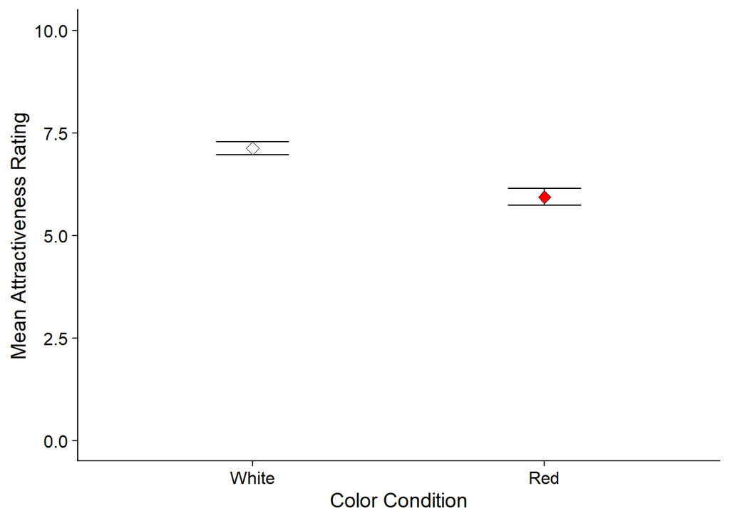

*Figure 3. Means plot of composite scores for attractiveness by condition*

# Discussion

Considering the findings from this study and the one made by Elliot et al (2010), it is important to note that there are different strengths and limitations to both studies, that may require further scrutiny.

Elliot et al (2010) included a very small sample size in their first experiment that compared the infleunce of red and white. Having 126 participants included in the final analysis of this study elevated the scope of population covered. However, future research could perhaps include an even bigger data with people from various cultures and countries. In fact, a study showed that in Chinese contexts, the color red may actually give higher mean ratings of attractiveness when women rate men in red shirts (Wen et al, 2014).

Furthermore, different hues of red may have distinct effects. The meta-analysis that was conducted in the realm of red and its effects on attractiveness revealed that displaying the original shade of red may actually have a detrimental affect in comparison to other variants of the color (Lehmann et al, 2018). As much as redness can be associated with that of high status, it can also be linked to expressions with negative connotations, such as shame, aggressiveness, and dominance (Boothroyd et al, 2007). Therefore, it is vital to further investigate whether different hues of red may have different impacts. This study used the same color code as the one used in the study conducted by Elliot et al (2010), so it failed to distinguish whether such discrepancies exist.

It may also be beneficial to try different displays of the color discriminated. For example, the study that was conducted on a Chinese population used clothing to discern the effects of color on perceived attractiveness, and their finding proved to be different from the one in this study (Wen et al, 2014). Thus it could be profitable to further examine whether particular ways of presenting the color red may influence attractiveness perception differently.

In summary, this experiment did not find that the presentation of different colored frames around the image of a moderately attractive man would elicit higher mean attractiveness ratings of him. However, future research may include a larger and more diverse sample of participants, a new experimental nuance of the color red, and the way that the colors are displayed could eventually be experimented on to see if effect sizes change.

# References

Boothroyd, L. G., Jones, B. C., Burt, D. M., and Perrett, D. I. (2007). Partner characteristics associated with masculinity, health and maturity in male faces. *Personality and Individual Differences, 43,* 1161–1173.

Elliot, A. J., Niesta Kayser, D., Greitemeyer, T., Lichtenfeld, S., Gramzow, R. H., Maier, M. A., & Liu, H. (2010). Red, rank, and romance in women viewing men. *Journal of Experimental Psychology: General, 139*(3), 399.

Lehmann, G. K., Elliot, A. J., & Calin-Jageman, R.J. (2018). Meta-Analysis of the Effect of Red on Perceived Attractiveness. *Evolutionary Psychology, 16*(4), 1-27.

Setchell, J. M. (2005). Do female mandrills (Mandrillus sphinx) prefer brightly coloured males? *International Journal of Primatology, 26,* 713–732.

Wen, F., Zuo, B., Wu, Y., Sun, S., Liu, K. (2014). Red is romantic, but only for feminine females: Sexual dimorphism moderates red effect on sexual attraction. Evolutionary Psychology, 12, 719–735.